# CSCI E-63C: Final Exam/Project

# Preface

For the final exam/project we will develop classification models using several approaches and compare their performance on a new dataset that is a subset of one of the datasets used in machine learning common task framework (CTF) competitions. A copy of it split into training (`final-data-train.csv`, with outcome `response` available) and test (`final-data-test.csv`, stripped of the outcome, for prediction purposes only) datasets is available on our course website in Canvas as a zip-archive of all associated files.

Please notice, that at the end of this final exam/project you will be asked, in addition to the Rmarkdown and HTML files, to also make predictions for the observations in the *test* (not training!) dataset and upload them into Canvas as well. The expected format for the file with predictions for test dataset is two columns of comma-separated values, one row per observation in *test* dataset, first column – the observation identifier (column `id` in test dataset) and the second column – your best model predictions for each observation in the *test* dataset as Y/N indicator. To illustrate expected format the zip archive contains also a couple of examples of test predictions in this format for your reference as well (`predictions-*.csv` files in `predictions-examples` sub-folder in zip-archive).

One more time, to iterate and emphasize, please notice that this time your submission must consist of the following *three* (not just two, Rmd+html, as usual) items:

- Rmarkdown *.Rmd file with all the calculations you want to receive credit for,
- HTML version of the output generated by your *.Rmd file, and
- **predictions** for the **test** dataset in comma-separated values (CSV) format (file name **must** have *.csv extension for the file to load in Canvas)

The teaching team invites you to load your predictions (just predictions, just for the test dataset according to the file format shown in the sample files in the zip-archive) into Canvas repeatedly as you work on your models and improve them over the course of this week. At least daily (or more frequently as we see fit) we will download predictions loaded by everyone by that time and compile a leaderboard in html format of all of them sorted by their accuracy as compared to the true values of the outcome for the test dataset (along with their sensitivity, specificity, etc.). This list will be made available on our course website in Canvas for everyone in this class in order to see how the performance of their models compares across the rest of the models built by other students in the class. The first version of the leaderboard posted on the course website at the time when final exam is made available starts with predictions made by those few example files provided in the zip-archive (coin flip, majority vote, etc. – what do you think Charlie Brown is using to make the predictions?). Those should be pretty easy to improve upon.

It is 100% up to you whether you want to upload your model predictions over the course of this week, how frequently you want to do it and what you want its results to be called in the leaderboard posted for everyone in the class to see. We will use the name of the 2nd column in the file with predictions (the one containing Y/N values, not the numerical ids of the observations) as the model name listed in the leaderboard. If you prefer not to use your name, choose something else instead, sufficiently unique so that it is easier for you to spot your result among all others. Once again, please check out sample files of dull (majority vote, coin flip, etc.) predictions we have made available and consider how they show up in the leaderboard html file already posted on Canvas website. Once you are done with final you are expected to load predictions from your best model into Canvas – that is part of your points total as explained below.

Lastly, the size of this dataset can make some of the modeling techniques run slower than what we were typically encountering in this class. You may find it helpful to do some of the exploration and model tuning on multiple random samples of smaller size as you decide on useful ranges of parameters/modeling choices, and then only perform a final run of fully debugged and working code on the full dataset. Please see also the afterword below on the computational demands of this problem set.

# Problem 1: univariate and unsupervised analysis (20 points)

Download and read training and test data into R and prepare graphical and numerical summaries of it: e.g. histograms of continuous attributes, contingency tables of categorical variables, scatterplots of continuous attributes with some of the categorical variables indicated by color/symbol shape, etc. Whatever you find helpful to think about properties of the data you are about to start using for fitting classification models.

As it is often the case for such contests, the attributes in the dataset are blinded in the sense that no information is available about what those are or what their values mean. The only information available is that the attribute `response` is the outcome to be modeled and the attribute `id` is the unique numerical identifier for each observation. Some of the remaining attributes are clearly categorical (those that are character valued) and some rather obviously continuous (those with numerical values with large number of unique values). For several of them it is less clear whether it is best to treat them as continuous or categorical – e.g. their values are numerical but there are relatively few unique values with many observations taking the same value, so that they arguably could be treated as continuous or categorical. Please idenify them, reflect on how you prefer to handle them and describe this in your own words.

Perform principal components analysis of this data (do you need to scale it prior to that? how would you represent multilevel categorical attributes to be used as inputs for PCA?) and plot observations in the space of the first few principal components indicating levels of some of the categorical attributes of your choosing by the color/shape of the symbol. Perform univariate assessment of associations between the outcome we will be modeling and each of the attributes (e.g. t-test or logistic regression for continuous attributes, contingency tables/Fisher exact test/$\chi^2$ test for categorical attributes). Summarize your observations from these assessments: does it appear that there are predictors associated with the outcome `response` univariately? Which predictors seem to be more/less relevant?

## Load Libraries and Raw Data

```r
library(ggplot2)
library(GGally)
library(gridExtra)
library(MASS)
library(glmnet)
library(randomForest)
library(reshape2)
```

```r
# read in the raw training data
raw.data <- read.csv("final-data-train.csv")
head(raw.data)
```

```
##   response     id wc zwp  wi     dtj bnf       qh ent      sci ypz      bw tdt
## 1        N 165931  d   R gnq 3.31662   J 1.619306   A 1.358321  11 0.31623  kc
## 2        N 241964  b   S gmz 0.00000   K 1.465870   A 1.421907  11 0.44698  sm
## 3        Y 387089  b   O gmz 3.46410   J 2.011248   A 1.427199  14 0.44721  zp
## 4        Y 433922  b   Q gmz 3.31662   L 1.915616   A 1.410130  10 0.38729  sm
## 5        N 175120  b   S gmz 3.74166   J 1.740224   A 1.361948   1 0.31623  zp
## 6        N 353214  e   R gmz 2.23607   I 1.656426   A 1.313058   0 0.39988  zp
##   sb ox  xt np ku      is
## 1 s2 bf fcc  j  y 0.24077
## 2 s2 fy ntb  j  v 3.76180
## 3 s2 ix ntb  j  u 2.49990
## 4 s2 bf ntb  k  x 2.47710
## 5 s2 bf ntb  j  z 4.17080
## 6 s2 jl ntb  j  z 2.94250
```

## Data Exploration

```r
# understanding the shape of the data frame
cat("Dims:", dim(raw.data))
```

```
## Dims: 30994 19
```

```r
cat("\n\n\n")
```

```r
str(raw.data)
```

```
## 'data.frame':    30994 obs. of  19 variables:
##  $ response: Factor w/ 2 levels "N","Y": 1 1 2 2 1 1 1 1 2 2 ...
##  $ id      : int  165931 241964 387089 433922 175120 353214 458159 512275 310008 91571 ...
##  $ wc      : Factor w/ 6 levels "a","b","c","d",..: 4 2 2 2 2 5 4 4 4 4 ...
##  $ zwp     : Factor w/ 13 levels "N","O","P","Q",..: 5 6 2 4 6 5 5 6 1 4 ...
##  $ wi      : Factor w/ 2 levels "gmz","gnq": 2 1 1 1 1 1 1 1 2 1 ...
##  $ dtj     : num  3.32 0 3.46 3.32 3.74 ...
##  $ bnf     : Factor w/ 8 levels "H","I","J","K",..: 3 4 3 5 3 2 3 3 4 3 ...
##  $ qh      : num  1.62 1.47 2.01 1.92 1.74 ...
##  $ ent     : Factor w/ 2 levels "A","B": 1 1 1 1 1 1 1 1 2 1 ...
##  $ sci     : num  1.36 1.42 1.43 1.41 1.36 ...
##  $ ypz     : int  11 11 14 10 1 0 1 1 14 1 ...
##  $ bw      : num  0.316 0.447 0.447 0.387 0.316 ...
##  $ tdt     : Factor w/ 4 levels "kc","kv","sm",..: 1 3 4 3 4 4 3 4 4 4 ...
##  $ sb      : Factor w/ 8 levels "s1","s2","s3",..: 2 2 2 2 2 2 2 2 2 2 ...
##  $ ox      : Factor w/ 4 levels "bf","fy","ix",..: 1 2 3 1 1 4 3 1 1 4 ...
##  $ xt      : Factor w/ 5 levels "dgk","fcc","gcn",..: 2 5 5 5 5 5 5 5 5 5 ...
##  $ np      : Factor w/ 2 levels "j","k": 1 1 1 2 1 1 1 1 1 2 ...
##  $ ku      : Factor w/ 8 levels "s","t","u","v",..: 7 4 3 6 8 8 7 3 5 6 ...
##  $ is      : num  0.241 3.762 2.5 2.477 4.171 ...
```

```r
cat("\n\n\n")
```

```r
summary(raw.data)
```

```
##  response        id         wc             zwp          wi
##  N:23356   Min.   :    47   a:   44   N      :10787   gmz:28424
##  Y: 7638   1st Qu.:149201   b:10047   R      :10241   gnq: 2570
##            Median :293876   c: 1187   S      : 3682
##            Mean   :296166   d:18803   O      : 2389
##            3rd Qu.:443656   e:  819   U      : 1317
##            Max.   :595209   f:   94   T      :  940
##                                       (Other): 1638
##       dtj             bnf             qh        ent            sci
##  Min.   :0.000   J      :9743   Min.   :1.310   A:24929   Min.   :1.110
##  1st Qu.:2.828   K      :7970   1st Qu.:1.661   B: 6065   1st Qu.:1.351
##  Median :3.317   I      :6391   Median :1.752             Median :1.371
##  Mean   :3.028   L      :3906   Mean   :1.793             Mean   :1.373
##  3rd Qu.:3.606   H      :1680   3rd Qu.:1.882             3rd Qu.:1.396
##  Max.   :3.742   M      :1216   Max.   :4.721             Max.   :1.592
##                  (Other):  88
##       ypz               bw         tdt              sb         ox
##  Min.   : 0.000   Min.   :0.1414   kc: 3392   s2     :28419   bf:13312
##  1st Qu.: 1.000   1st Qu.:0.3162   kv: 1024   s8     :  765   fy: 9062
##  Median : 6.000   Median :0.3742   sm: 9597   s6     :  583   ix: 1860
##  Mean   : 6.383   Mean   :0.3760   zp:16981   s5     :  427   jl: 6760
##  3rd Qu.:11.000   3rd Qu.:0.4000              s1     :  312
##  Max.   :17.000   Max.   :1.2649              s3     :  250
##                                               (Other):  238
##    xt        np              ku              is
##  dgk: 1540   j:23792   z      :10500   Min.   : 0.00011
##  fcc: 6648   k: 7202   y      : 7552   1st Qu.: 0.86299
##  gcn:   22             x      : 4280   Median : 1.80825
##  mrm:  311             u      : 3110   Mean   : 2.15407
##  ntb:22473             w      : 2524   3rd Qu.: 3.08935
##                        v      : 1249   Max.   :16.02500
##                        (Other): 1779
```

```r
cat("\n\n\n")
```

```r
#check for NA values
sapply(raw.data, function(x) sum(is.na(x)))
```

```
## response       id       wc      zwp       wi      dtj      bnf       qh
##        0        0        0        0        0        0        0        0
##      ent      sci      ypz       bw      tdt       sb       ox       xt
##        0        0        0        0        0        0        0        0
##       np       ku       is
##        0        0        0
```

Raw contingency tables:

```r
# discrete variable contingency tables
discrete.list <- list(
    "wc",
    "zwp",
    "wi",
    "bnf",
    "ypz",
    "tdt",
    "sb",
    "xt",
    "np"
)

for (i in 1:length(discrete.list)){
    print(discrete.list[[i]])
    print(table(raw.data[,1],raw.data[,discrete.list[[i]]]))
    cat("\n")
}
```

```
## [1] "wc"
##
##         a     b     c     d     e     f
##   N    17  7893   344 14450   639    13
##   Y    27  2154   843  4353   180    81
##
## [1] "zwp"
##
##        N    O    P    Q    R    S    T    U    V    W    X    Y    Z
##   N 7631 1759  112   76 8788 3205  724  946   69    9   11   26    0
##   Y 3156  630  619  377 1453  477  216  371  108   35   32  143   21
##
## [1] "wi"
##
##       gmz   gnq
##   N 22821   535
##   Y  5603  2035
##
## [1] "bnf"
##
##        H    I    J    K    L    M    N    O
##   N 1255 4852 7367 5994 2915  949   21    3
##   Y  425 1539 2376 1976  991  267   59    5
##
## [1] "ypz"
##
##        0    1    2    3    4    5    6    7    8    9   10   11   12   13   14
##   N 4665 5238    8  394 1287   21  839  622   10  427 1113 5553   94   96 2311
##   Y 1246 1261   54  173  321   42  245  214   46  427  564 1396   42  179  695
##
##       15   16   17
##   N  512   90   76
##   Y  502   90  141
##
## [1] "tdt"
##
##        kc    kv    sm    zp
##   N  2888   460  6810 13198
##   Y   504   564  2787  3783
##
## [1] "sb"
##
##        s1    s2    s3    s4    s5    s6    s7    s8
##   N    32 22737    55    19   311    85    10   107
##   Y   280  5682   195   166   116   498    43   658
##
## [1] "xt"
##
##       dgk   fcc   gcn   mrm   ntb
##   N  1174  5001     0    82 17099
##   Y   366  1647    22   229  5374
##
## [1] "np"
##
##         j     k
##   N 19113  4243
##   Y  4679  2959
```

Compare Y/N responses across multiple variables and treatments:

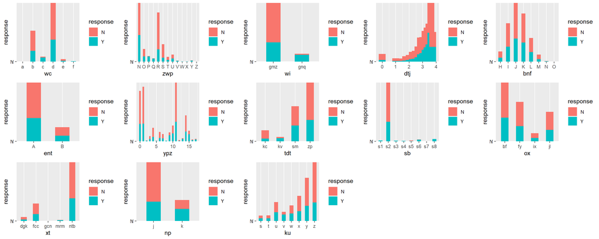

```r
#Y/N comparison across several attributes
plot.1 <- ggplot(raw.data, aes(x=wc, y=response, fill=response)) +
    geom_bar(stat = "identity", width = .5)
plot.2 <- ggplot(raw.data, aes(x=zwp, y=response, fill=response)) +
    geom_bar(stat = "identity", width = .5)
plot.3 <- ggplot(raw.data, aes(x=wi, y=response, fill=response)) +
    geom_bar(stat = "identity", width = .5)
plot.4 <- ggplot(raw.data, aes(x=dtj, y=response, fill=response)) +
    geom_bar(stat = "identity", width = .5)
plot.5 <- ggplot(raw.data, aes(x=bnf, y=response, fill=response)) +
    geom_bar(stat = "identity", width = .5)
plot.6 <- ggplot(raw.data, aes(x=ent, y=response, fill=response)) +
    geom_bar(stat = "identity", width = .5)
plot.7 <- ggplot(raw.data, aes(x=ypz, y=response, fill=response)) +
    geom_bar(stat = "identity", width = .5)
plot.8 <- ggplot(raw.data, aes(x=tdt, y=response, fill=response)) +
    geom_bar(stat = "identity", width = .5)
plot.9 <- ggplot(raw.data, aes(x=sb, y=response, fill=response)) +
    geom_bar(stat = "identity", width = .5)
plot.10 <- ggplot(raw.data, aes(x=ox, y=response, fill=response)) +
    geom_bar(stat = "identity", width = .5)
plot.11 <- ggplot(raw.data, aes(x=xt, y=response, fill=response)) +
    geom_bar(stat = "identity", width = .5)
plot.12 <- ggplot(raw.data, aes(x=np, y=response, fill=response)) +
    geom_bar(stat = "identity", width = .5)
plot.13 <- ggplot(raw.data, aes(x=ku, y=response, fill=response)) +
    geom_bar(stat = "identity", width = .5)
grid.arrange(plot.1,
             plot.2,
             plot.3,
             plot.4,
             plot.5,
             plot.6,
             plot.7,
             plot.8,
             plot.9,
             plot.10,
             plot.11,
             plot.12,
             plot.13,
             ncol = 5)
```

```r
# function to analyze the success rate by category
success.rate.by.level <- function(column){
    lvls <- levels(column)
    total <- length(column)
    counts <- numeric()
    rates <- numeric()
    Ycounts <- numeric()
    Yrates <- numeric()
    i <- 1
    for (l in 1:length(lvls)){
        counts[i] <- nrow(raw.data[column == lvls[l],])
        rates[i] <- 100 * (counts[i] / total)
        Ycounts[i] <- nrow(raw.data[column == lvls[l] & raw.data$response == "Y",])
        Yrates[i] <- 100 * (Ycounts[i] / counts[i])
        i <- i + 1
    }
    result <- as.data.frame(cbind(counts, rates, Ycounts, Yrates))
    result <- cbind(lvls, result)
    result <- result[order(Yrates),]
    result[,1] <- factor(result[,1], levels = result[,1])
    return(result)
}
```

```r
#calculate success rates
rates.wc <- success.rate.by.level(raw.data$wc)
rates.zwp <- success.rate.by.level(raw.data$zwp)
rates.wi <- success.rate.by.level(raw.data$wi)
rates.bnf <- success.rate.by.level(raw.data$bnf)
rates.ent <- success.rate.by.level(raw.data$ent)
rates.ypz <- success.rate.by.level(factor(raw.data$ypz))
rates.tdt <- success.rate.by.level(raw.data$tdt)
rates.sb <- success.rate.by.level(raw.data$sb)
rates.ox <- success.rate.by.level(raw.data$ox)
rates.xt <- success.rate.by.level(raw.data$xt)
rates.np <- success.rate.by.level(raw.data$np)
rates.ku <- success.rate.by.level(raw.data$ku)
rates.wc
```

```
##   lvls counts      rates Ycounts   Yrates
## 2    b  10047 32.4159515    2154 21.43924
## 5    e    819  2.6424469     180 21.97802
## 4    d  18803 60.6665806    4353 23.15056
## 1    a     44  0.1419630      27 61.36364
## 3    c   1187  3.8297735     843 71.01938
## 6    f     94  0.3032845      81 86.17021
```

```r
rates.zwp
```

```
##    lvls counts       rates Ycounts    Yrates
## 6     S   3682 11.87971866     477  12.95492
## 5     R  10241 33.04187907    1453  14.18807
## 7     T    940  3.03284507     216  22.97872
## 2     O   2389  7.70794347     630  26.37087
## 8     U   1317  4.24920952     371  28.17008
## 1     N  10787 34.80351036    3156  29.25744
## 9     V    177  0.57107827     108  61.01695
## 11    X     43  0.13873653      32  74.41860
## 10    W     44  0.14196296      35  79.54545
## 4     Q    453  1.46157321     377  83.22296
## 12    Y    169  0.54526683     143  84.61538
## 3     P    731  2.35852100     619  84.67852
## 13    Z     21  0.06775505      21 100.00000
```

```r
rates.wi
```

```
##   lvls counts     rates Ycounts   Yrates
## 1  gmz  28424 91.708073    5603 19.71222
## 2  gnq   2570  8.291927    2035 79.18288
```

```r
rates.bnf
```

```
##   lvls counts       rates Ycounts   Yrates
## 6    M   1216  3.92334000     267 21.95724
## 2    I   6391 20.62012002    1539 24.08074
## 3    J   9743 31.43511647    2376 24.38674
## 4    K   7970 25.71465445    1976 24.79297
## 1    H   1680  5.42040395     425 25.29762
## 5    L   3906 12.60243918     991 25.37122
## 8    O      8  0.02581145       5 62.50000
## 7    N     80  0.25811447      59 73.75000
```

```r
rates.ypz
```

```
##    lvls counts      rates Ycounts   Yrates
## 2     1   6499 20.9685746    1261 19.40299
## 5     4   1608  5.1881009     321 19.96269
## 12   11   6949 22.4204685    1396 20.08922
## 1     0   5911 19.0714332    1246 21.07934
## 7     6   1084  3.4974511     245 22.60148
## 15   14   3006  9.6986514     695 23.12043
## 8     7    836  2.6972963     214 25.59809
## 4     3    567  1.8293863     173 30.51146
## 13   12    136  0.4387946      42 30.88235
## 11   10   1677  5.4107247     564 33.63148
## 16   15   1014  3.2716010     502 49.50690
## 10    9    854  2.7553720     427 50.00000
## 17   16    180  0.5807576      90 50.00000
## 18   17    217  0.7001355     141 64.97696
## 14   13    275  0.8872685     179 65.09091
## 6     5     63  0.2032651      42 66.66667
## 9     8     56  0.1806801      46 82.14286
## 3     2     62  0.2000387      54 87.09677
```

```r
rates.tdt
```

```
##   lvls counts     rates Ycounts   Yrates
## 1   kc   3392 10.944054     504 14.85849
## 4   zp  16981 54.788023    3783 22.27784
## 3   sm   9597 30.964058    2787 29.04033
## 2   kv   1024  3.303865     564 55.07812
```

```r
rates.sb
```

```
##   lvls counts      rates Ycounts   Yrates
## 2   s2  28419 91.6919404    5682 19.99367
## 5   s5    427  1.3776860     116 27.16628
## 3   s3    250  0.8066077     195 78.00000
## 7   s7     53  0.1710008      43 81.13208
## 6   s6    583  1.8810092     498 85.42024
## 8   s8    765  2.4682197     658 86.01307
## 4   s4    185  0.5968897     166 89.72973
## 1   s1    312  1.0066464     280 89.74359
```

```r
rates.xt
```

```
##   lvls counts       rates Ycounts    Yrates
## 1  dgk   1540  4.96870362     366  23.76623
## 5  ntb  22473 72.50758211    5374  23.91314
## 2  fcc   6648 21.44931277    1647  24.77437
## 4  mrm    311  1.00342002     229  73.63344
## 3  gcn     22  0.07098148      22 100.00000
```

```r
rates.np
```

```
##   lvls counts    rates Ycounts   Yrates
## 1    j  23792 76.76324    4679 19.66627
## 2    k   7202 23.23676    2959 41.08581
```

```r
rates.ku
```

```
##   lvls counts     rates Ycounts   Yrates
## 8    z  10500 33.877525    1962 18.68571
## 7    y   7552 24.366006    1619 21.43803
## 6    x   4280 13.809124    1043 24.36916
## 3    u   3110 10.034200     926 29.77492
## 5    w   2524  8.143512     794 31.45800
## 2    t    901  2.907014     300 33.29634
## 1    s    878  2.832806     293 33.37130
## 4    v   1249  4.029812     701 56.12490
```

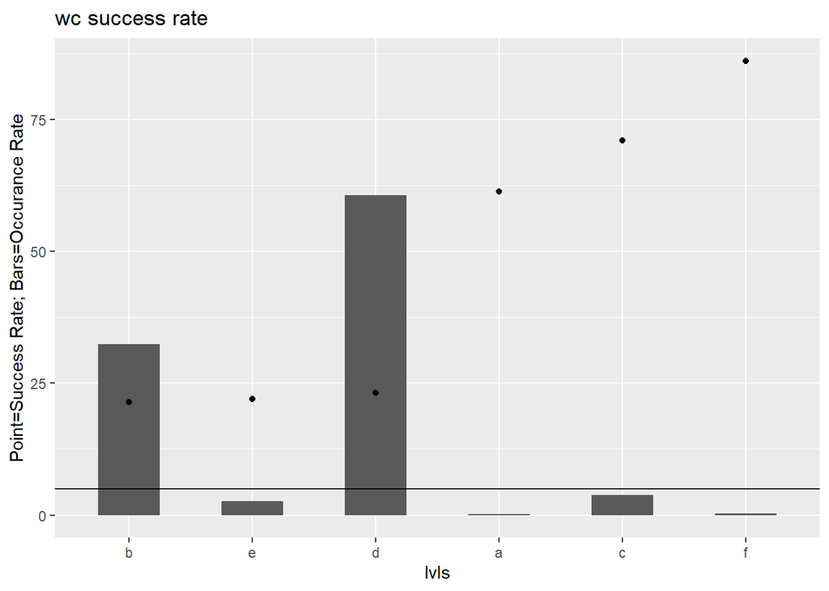

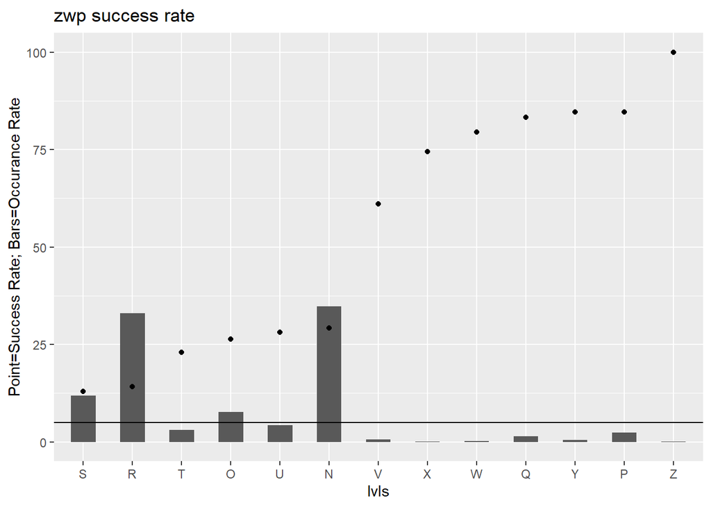

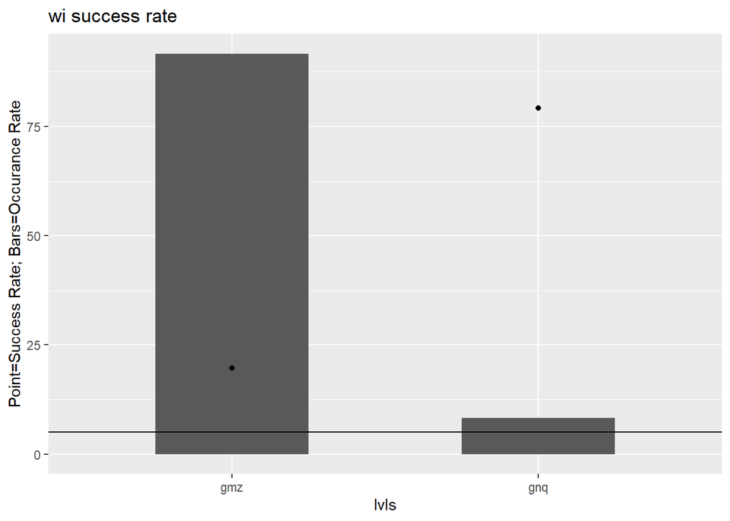

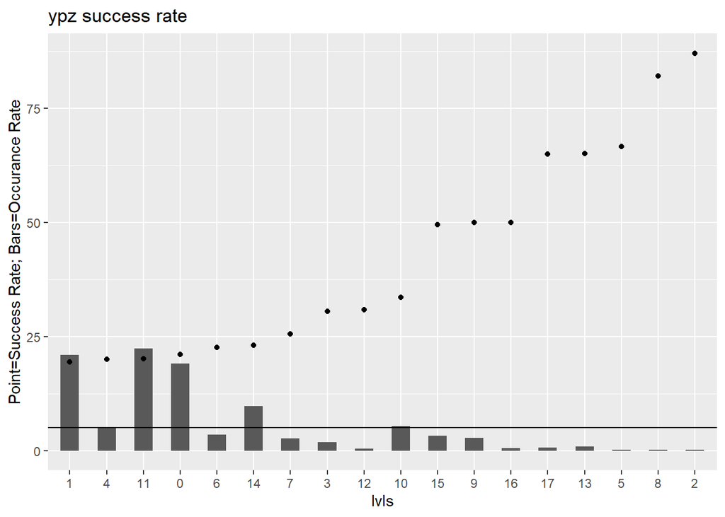

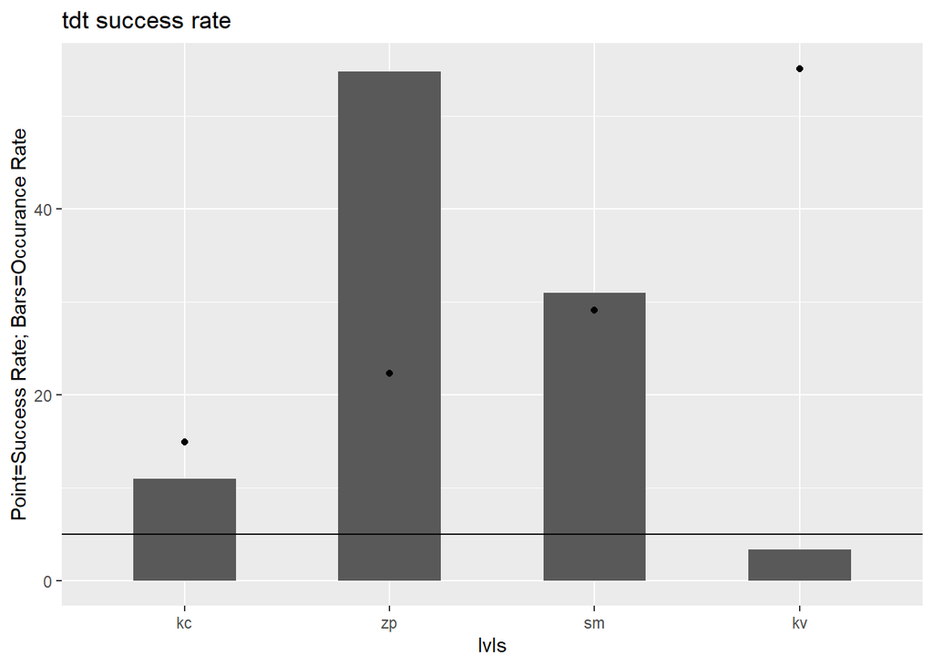

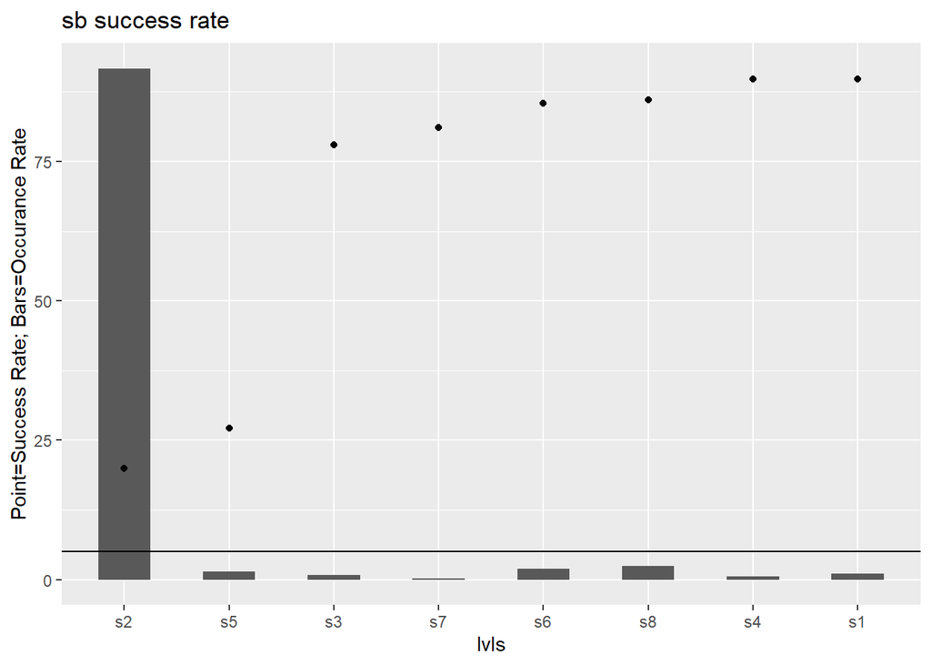

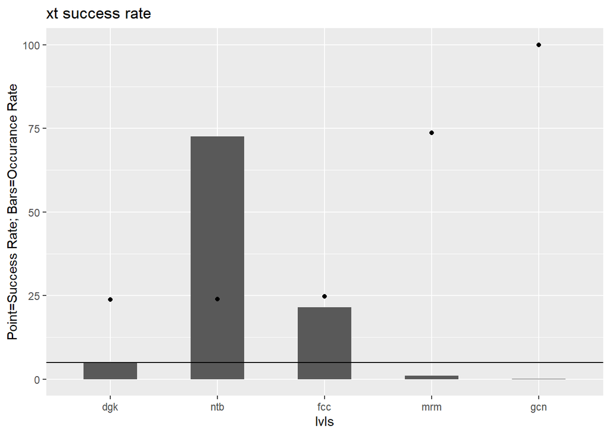

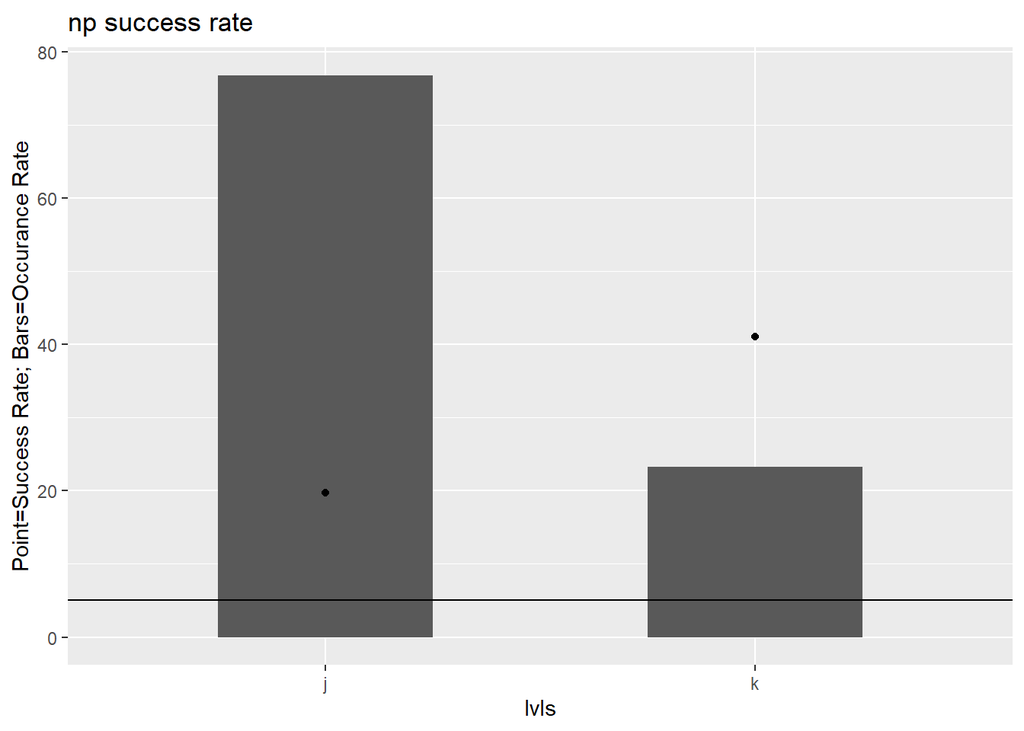

```r
# success rates for discrete variables plotted
plot.list <- vector(mode = "list", length = 9)
rates.list <- list(
    rates.wc,
    rates.zwp,
    rates.wi,
    rates.ypz,
    rates.tdt,
    rates.sb,
    rates.xt,
    rates.np
)

discrete.list <- list(
    "wc",
    "zwp",
    "wi",
    "ypz",
    "tdt",
    "sb",
    "xt",
    "np"
)

for (i in 1:8){
    tmp.name <- paste0(discrete.list[[i]])
    tmp.name <- ggplot(data = rates.list[[i]], aes(x=lvls, y=Yrates)) +
        geom_bar(data = rates.list[[i]], aes(x=lvls, y=rates), stat="identity", width = .5) +
        geom_point() +
        ggtitle(paste0(tmp.name, " success rate")) +
        ylab("Point=Success Rate; Bars=Occurance Rate") +
        geom_hline(yintercept = 5)
    plot.list[[i]] <- tmp.name
}

plot.list
```

## Preprocessing

Preprocessing operations:

```r
# make the id column the row names and remove it as a variable
pp.data.1 <- raw.data
rownames(pp.data.1) <- pp.data.1$id
pp.data.1$id <- NULL

# remove non-relevant variables
pp.data.1$ent <- NULL
pp.data.1$ox <- NULL
pp.data.1$bnf <- NULL

# wc: combine a/c/f; combine b/e; make 3 levels
pp.data.1$wc <- as.character(pp.data.1$wc)
pp.data.1$wc[pp.data.1$wc == "a" | pp.data.1$wc == "c" | pp.data.1$wc == "f"] <- "acf"
pp.data.1$wc[pp.data.1$wc != "acf" & pp.data.1$wc != "d"] <- "be"
pp.data.1$wc <- as.factor(pp.data.1$wc)

# zwp: combine S/R; combine T/O/U/N; combine V/X/W/Q/Y/P/Z; make 3 levels
pp.data.1$zwp <- as.character(pp.data.1$zwp)
pp.data.1$zwp[pp.data.1$zwp == "S" | pp.data.1$zwp == "R"] <- "SR"
pp.data.1$zwp[pp.data.1$zwp == "T" | pp.data.1$zwp == "O" | pp.data.1$zwp == "U" | pp.data.1$zwp == "N"] <- "TOUN"
pp.data.1$zwp[pp.data.1$zwp != "SR" & pp.data.1$zwp != "TOUN"] <- "VXWQYPZ"
pp.data.1$zwp <- as.factor(pp.data.1$zwp)

# ypz: combine 1/4/11/0/6/14/7; combine 3/12/10; combine 15/19/16; combine 17/13/5/8/2; make 4 levels
pp.data.1$ypz <- as.character(pp.data.1$ypz)
pp.data.1$ypz[pp.data.1$ypz == "3" | pp.data.1$ypz == "12"| pp.data.1$ypz == "10"] <- "3,12,10"
pp.data.1$ypz[pp.data.1$ypz == "15" | pp.data.1$ypz == "19"| pp.data.1$ypz == "16"] <- "15,19,16"
pp.data.1$ypz[pp.data.1$ypz == "17" | pp.data.1$ypz == "13"| pp.data.1$ypz == "5" | pp.data.1$ypz == "8"| pp.data.1$ypz == "2"] <- "17,13,5,8,2"
pp.data.1$ypz[pp.data.1$ypz != "3,12,10" & pp.data.1$ypz != "3,12,10" & pp.data.1$ypz != "17,13,5,8,2"] <- "1,4,11,0,6,14,7"
pp.data.1$ypz <- as.factor(pp.data.1$ypz)

#combine sb into s2/s5 and not s2/s5
pp.data.1$sb <- as.character(pp.data.1$sb)
pp.data.1$sb[(pp.data.1$sb == "s2") | (pp.data.1$sb == "s5")] <- "s2s5"
pp.data.1$sb[pp.data.1$sb != "s2s5"] <- "s1s3s4s6s7s8"
pp.data.1$sb <- as.factor(pp.data.1$sb)

# xt: combine dgk/ntb/fcc; combine mrm/gcn; make 2 levels
pp.data.1$xt <- as.character(pp.data.1$xt)
pp.data.1$xt[(pp.data.1$xt == "mrm") | (pp.data.1$xt == "gcn")] <- "mrm,gcn"
pp.data.1$xt[pp.data.1$xt != "mrm,gcn"] <- "dgk,ntb,fcc"
pp.data.1$xt <- as.factor(pp.data.1$xt)

# ku: create ordered factors to treat ku as continuous
pp.data.1$ku <- factor(pp.data.1$ku, levels = rates.ku[,1])
pp.data.1$ku <- as.numeric(pp.data.1$ku)

#rearrange to continuous and discrete
continuous.vec <- c("response", "dtj", "qh", "sci", "bw", "ku", "is")
discrete.vec <- c("response", unlist(discrete.list, use.names = FALSE))
colorder <- c(continuous.vec, discrete.vec[2:length(discrete.vec)])
pp.data.1 <- pp.data.1[,colorder]
head(pp.data.1)
```

```
##        response     dtj       qh      sci      bw ku      is wc     zwp  wi
## 165931        N 3.31662 1.619306 1.358321 0.31623  2 0.24077  d      SR gnq
## 241964        N 0.00000 1.465870 1.421907 0.44698  8 3.76180 be      SR gmz
## 387089        Y 3.46410 2.011248 1.427199 0.44721  4 2.49990 be    TOUN gmz
## 433922        Y 3.31662 1.915616 1.410130 0.38729  3 2.47710 be VXWQYPZ gmz
## 175120        N 3.74166 1.740224 1.361948 0.31623  1 4.17080 be      SR gmz
## 353214        N 2.23607 1.656426 1.313058 0.39988  1 2.94250 be      SR gmz
##                    ypz tdt   sb          xt np
## 165931 1,4,11,0,6,14,7  kc s2s5 dgk,ntb,fcc  j
## 241964 1,4,11,0,6,14,7  sm s2s5 dgk,ntb,fcc  j
## 387089 1,4,11,0,6,14,7  zp s2s5 dgk,ntb,fcc  j
## 433922         3,12,10  sm s2s5 dgk,ntb,fcc  k
## 175120 1,4,11,0,6,14,7  zp s2s5 dgk,ntb,fcc  j
## 353214 1,4,11,0,6,14,7  zp s2s5 dgk,ntb,fcc  j
```

```r
#subset data for testing models
sampled.rows <- sample(seq(1, nrow(pp.data.1)),ceiling(0.2*nrow(pp.data.1)),replace = FALSE)
model.test.data <- pp.data.1[sampled.rows,]
dim(model.test.data)
```

```
## [1] 6199   15
```

```r
#subset data for testing code
xs.sampled.rows <- sample(seq(1, nrow(pp.data.1)),ceiling(1/31*nrow(pp.data.1)),replace = FALSE)
xs.model.test.data <- pp.data.1[xs.sampled.rows,]
dim(xs.model.test.data)
```

```
## [1] 1000   15
```

The shape and summary of the preprocessed data:

```r
# understanding the shape of the new data frame
cat("Dims:", dim(pp.data.1))
```

```
## Dims: 30994 15
```

```r
cat("\n\n\n")
```

```r
str(pp.data.1)
```

```
## 'data.frame':    30994 obs. of  15 variables:
##  $ response: Factor w/ 2 levels "N","Y": 1 1 2 2 1 1 1 1 2 2 ...
##  $ dtj     : num  3.32 0 3.46 3.32 3.74 ...
##  $ qh      : num  1.62 1.47 2.01 1.92 1.74 ...
##  $ sci     : num  1.36 1.42 1.43 1.41 1.36 ...
##  $ bw      : num  0.316 0.447 0.447 0.387 0.316 ...
##  $ ku      : num  2 8 4 3 1 1 2 4 5 3 ...
##  $ is      : num  0.241 3.762 2.5 2.477 4.171 ...
##  $ wc      : Factor w/ 3 levels "acf","be","d": 3 2 2 2 2 2 3 3 3 3 ...
##  $ zwp     : Factor w/ 3 levels "SR","TOUN","VXWQYPZ": 1 1 2 3 1 1 1 1 2 3 ...
##  $ wi      : Factor w/ 2 levels "gmz","gnq": 2 1 1 1 1 1 1 1 2 1 ...
##  $ ypz     : Factor w/ 3 levels "1,4,11,0,6,14,7",..: 1 1 1 3 1 1 1 1 1 1 ...
##  $ tdt     : Factor w/ 4 levels "kc","kv","sm",..: 1 3 4 3 4 4 3 4 4 4 ...
##  $ sb      : Factor w/ 2 levels "s1s3s4s6s7s8",..: 2 2 2 2 2 2 2 2 2 2 ...
##  $ xt      : Factor w/ 2 levels "dgk,ntb,fcc",..: 1 1 1 1 1 1 1 1 1 1 ...
##  $ np      : Factor w/ 2 levels "j","k": 1 1 1 2 1 1 1 1 1 2 ...
```

```r
cat("\n\n\n")
```

```r
summary(pp.data.1)
```

```
##  response       dtj              qh             sci              bw
##  N:23356   Min.   :0.000   Min.   :1.310   Min.   :1.110   Min.   :0.1414
##  Y: 7638   1st Qu.:2.828   1st Qu.:1.661   1st Qu.:1.351   1st Qu.:0.3162
##            Median :3.317   Median :1.752   Median :1.371   Median :0.3742
##            Mean   :3.028   Mean   :1.793   Mean   :1.373   Mean   :0.3760
##            3rd Qu.:3.606   3rd Qu.:1.882   3rd Qu.:1.396   3rd Qu.:0.4000
##            Max.   :3.742   Max.   :4.721   Max.   :1.592   Max.   :1.2649
##        ku              is             wc             zwp          wi
##  Min.   :1.000   Min.   : 0.00011   acf: 1325   SR     :13923   gmz:28424
##  1st Qu.:1.000   1st Qu.: 0.86299   be :10866   TOUN   :15433   gnq: 2570
##  Median :2.000   Median : 1.80825   d  :18803   VXWQYPZ: 1638
##  Mean   :2.744   Mean   : 2.15407
##  3rd Qu.:4.000   3rd Qu.: 3.08935
##  Max.   :8.000   Max.   :16.02500
##               ypz        tdt                   sb                  xt
##  1,4,11,0,6,14,7:27941   kc: 3392   s1s3s4s6s7s8: 2148   dgk,ntb,fcc:30661
##  17,13,5,8,2    :  673   kv: 1024   s2s5        :28846   mrm,gcn    :  333
##  3,12,10        : 2380   sm: 9597
##                          zp:16981
##
##
##  np
##  j:23792
##  k: 7202
##
##
##
##
```

```r
cat("\n\n\n")
```

```r
#check for NA values
sapply(pp.data.1, function(x) sum(is.na(x)))
```

```
## response      dtj       qh      sci       bw       ku       is       wc
##        0        0        0        0        0        0        0        0
##      zwp       wi      ypz      tdt       sb       xt       np
##        0        0        0        0        0        0        0
```

### Discrete Data - Processed

Contingency Table for Combined of Treatments of Categorical Variables:

```r
# discrete variable contingency tables
for (i in 8:15){
    print(names(pp.data.1)[i])
    print(table(pp.data.1[,1], pp.data.1[,i]))
    cat("\n")
}
```

```
## [1] "wc"
##
##       acf    be     d
##   N   374  8532 14450
##   Y   951  2334  4353
##
## [1] "zwp"
##
##        SR  TOUN VXWQYPZ
##   N 11993 11060     303
##   Y  1930  4373    1335
##
## [1] "wi"
##
##       gmz   gnq
##   N 22821   535
##   Y  5603  2035
##
## [1] "ypz"
##
##     1,4,11,0,6,14,7 17,13,5,8,2 3,12,10
##   N           21544         211    1601
##   Y            6397         462     779
##
## [1] "tdt"
##
##        kc    kv    sm    zp
##   N  2888   460  6810 13198
##   Y   504   564  2787  3783
##
## [1] "sb"
##
##     s1s3s4s6s7s8  s2s5
##   N          308 23048
##   Y         1840  5798
##
## [1] "xt"
##
##     dgk,ntb,fcc mrm,gcn
##   N       23274      82
##   Y        7387     251
##
## [1] "np"
##
##         j     k
##   N 19113  4243
##   Y  4679  2959
```

A better way to visualize the data than the information in the contingency tables is below using the success rate function I created:

```r
#calculate success rates with reduced categories
rates.wc <- success.rate.by.level(pp.data.1$wc)
rates.zwp <- success.rate.by.level(pp.data.1$zwp)
rates.wi <- success.rate.by.level(pp.data.1$wi)
rates.ypz <- success.rate.by.level(factor(pp.data.1$ypz))
rates.tdt <- success.rate.by.level(pp.data.1$tdt)
rates.sb <- success.rate.by.level(pp.data.1$sb)
rates.xt <- success.rate.by.level(pp.data.1$xt)
rates.np <- success.rate.by.level(pp.data.1$np)
rates.wc
```

```
##   lvls counts     rates Ycounts   Yrates
## 2   be  10866 35.058398    2334 21.47985
## 3    d  18803 60.666581    4353 23.15056
## 1  acf   1325  4.275021     951 71.77358
```

```r
rates.zwp
```

```
##      lvls counts     rates Ycounts   Yrates
## 1      SR  13923 44.921598    1930 13.86196
## 2    TOUN  15433 49.793508    4373 28.33539
## 3 VXWQYPZ   1638  5.284894    1335 81.50183
```

```r
rates.wi
```

```
##   lvls counts     rates Ycounts   Yrates
## 1  gmz  28424 91.708073    5603 19.71222
## 2  gnq   2570  8.291927    2035 79.18288
```

```r
rates.ypz
```

```
##              lvls counts     rates Ycounts   Yrates
## 1 1,4,11,0,6,14,7  27941 90.149706    6397 22.89467
## 3         3,12,10   2380  7.678906     779 32.73109
## 2     17,13,5,8,2    673  2.171388     462 68.64785
```

```r
rates.tdt
```

```
##   lvls counts     rates Ycounts   Yrates
## 1   kc   3392 10.944054     504 14.85849
## 4   zp  16981 54.788023    3783 22.27784
## 3   sm   9597 30.964058    2787 29.04033
## 2   kv   1024  3.303865     564 55.07812
```

```r
rates.sb
```

```
##           lvls counts     rates Ycounts   Yrates
## 2         s2s5  28846 93.069626    5798 20.09984
## 1 s1s3s4s6s7s8   2148  6.930374    1840 85.66108
```

```r
rates.xt
```

```
##          lvls counts     rates Ycounts   Yrates
## 1 dgk,ntb,fcc  30661 98.925599    7387 24.09250
## 2     mrm,gcn    333  1.074401     251 75.37538
```

```r
rates.np
```

```
##   lvls counts    rates Ycounts   Yrates
## 1    j  23792 76.76324    4679 19.66627
## 2    k   7202 23.23676    2959 41.08581
```

```r
rates.list <- list(
    rates.wc,
    rates.zwp,
    rates.wi,
    rates.ypz,
    rates.tdt,
    rates.sb,
    rates.xt,
    rates.np
)
```

Replot the success rate data with the reduced number of treatments for categorical variables:

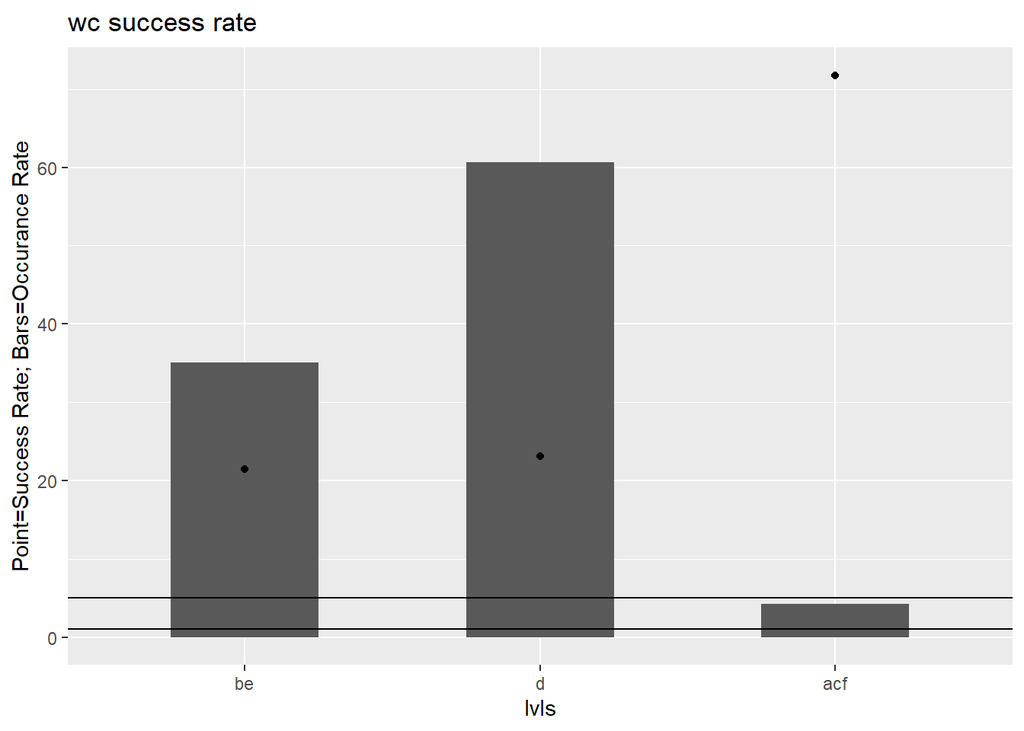

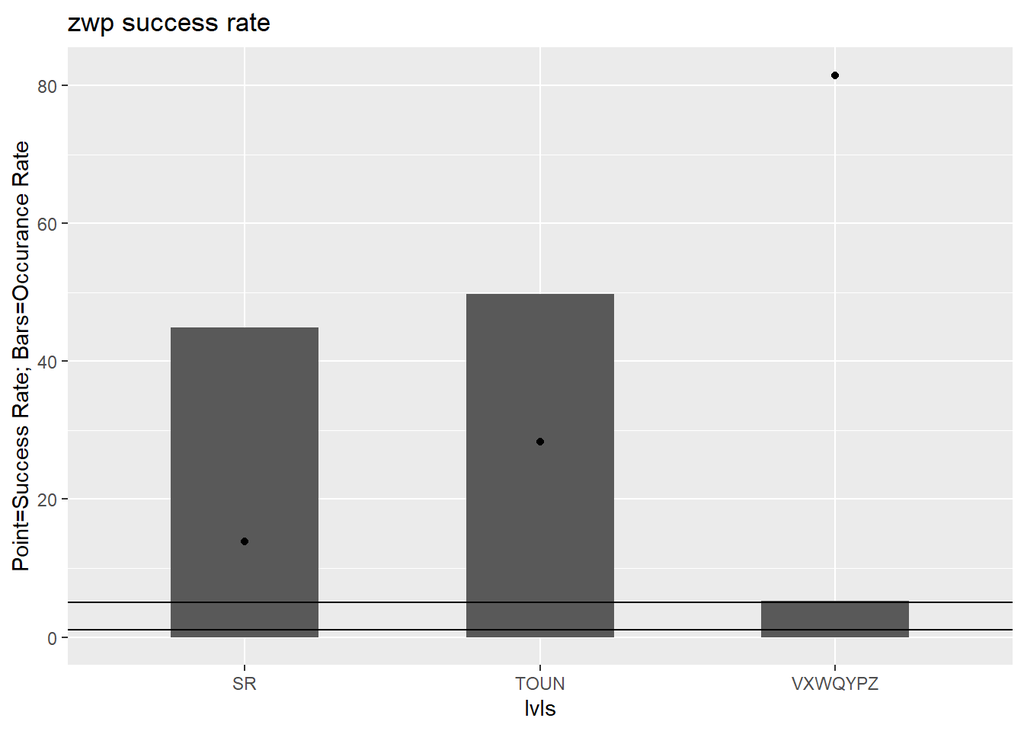

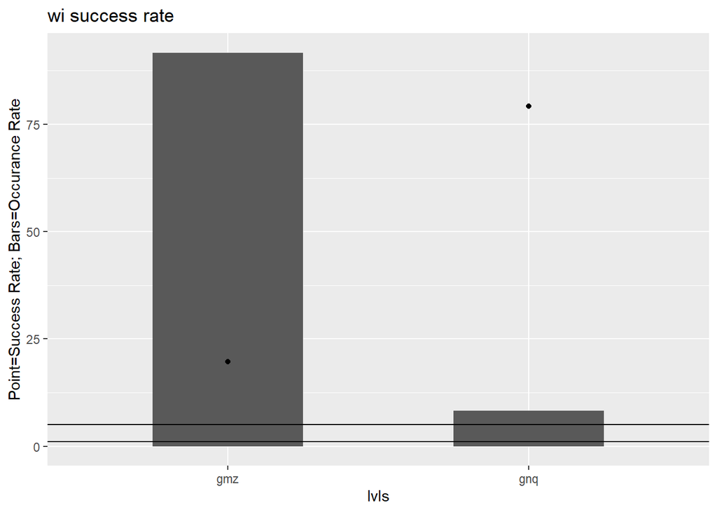

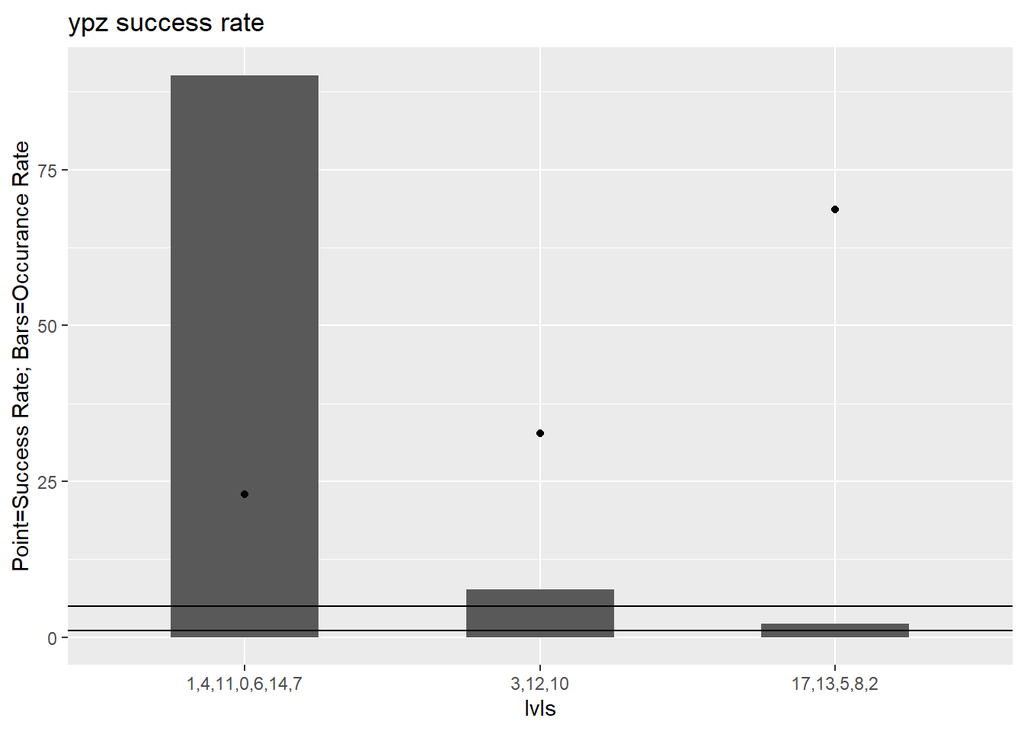

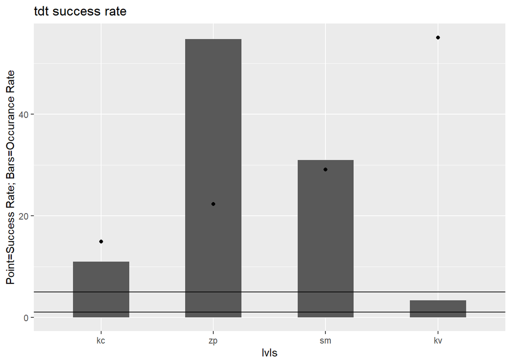

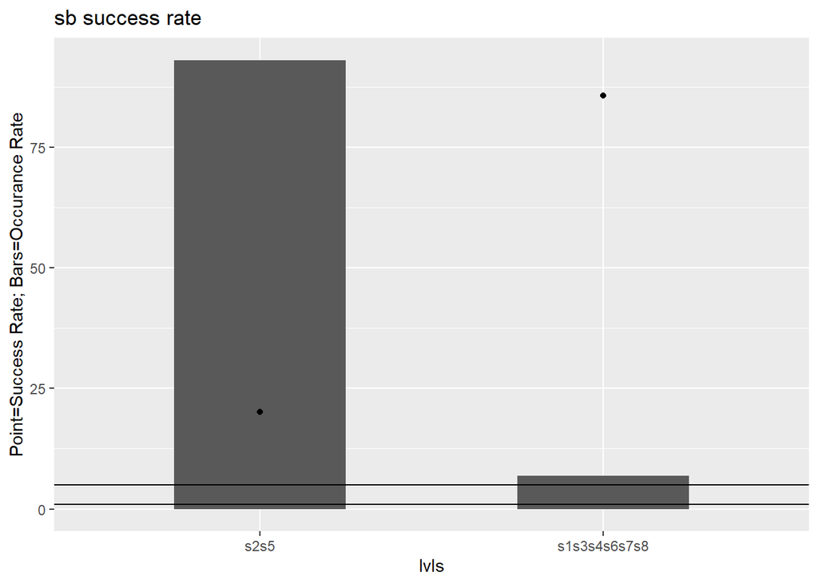

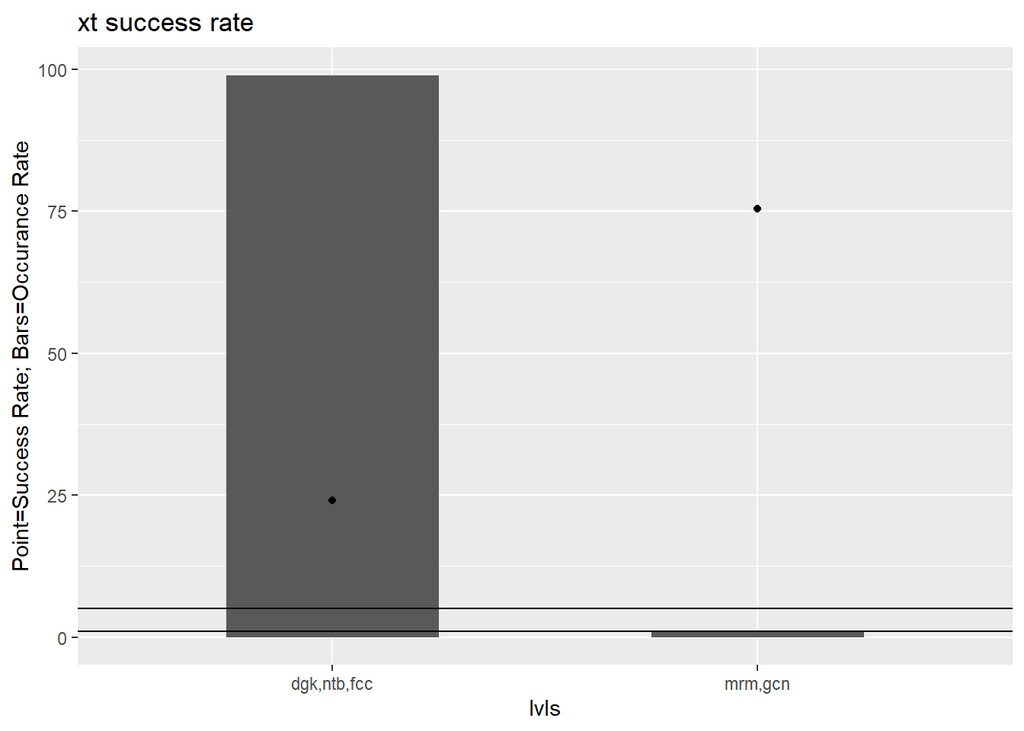

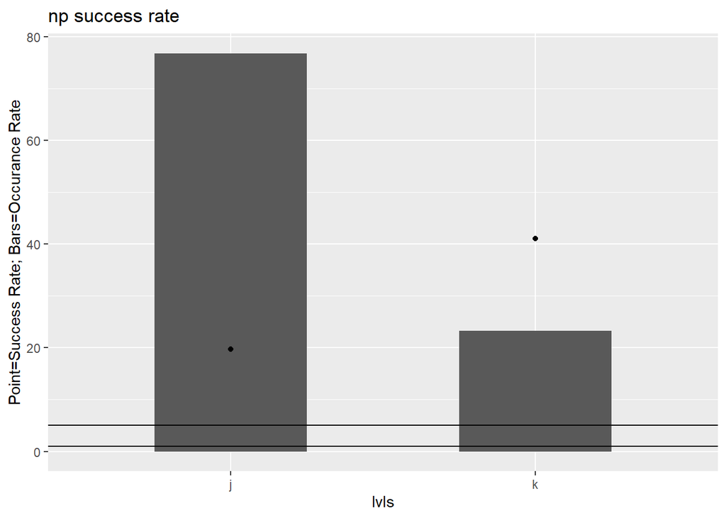

```r
# success rates for discrete variables plotted
plot.list <- vector(mode = "list", length = 8)

for (i in 1:length(plot.list)){
    tmp.name <- paste0(discrete.list[[i]])
    tmp.name <- ggplot(data = rates.list[[i]], aes(x=lvls, y=Yrates)) +
        geom_bar(data = rates.list[[i]], aes(x=lvls, y=rates), stat="identity", width = .5) +
        geom_point() +
        ggtitle(paste0(tmp.name, " success rate")) +
        ylab("Point=Success Rate; Bars=Occurance Rate") +
        geom_hline(yintercept = 5) +
        geom_hline(yintercept = 1)
    plot.list[[i]] <- tmp.name
}

plot.list
```

Consider dropping xt later due to low variance. Examine using the fisher exact test later.

### Continuous Data - Processed

Histograms of the continuous data to see if they have a normal or near normal distribution:

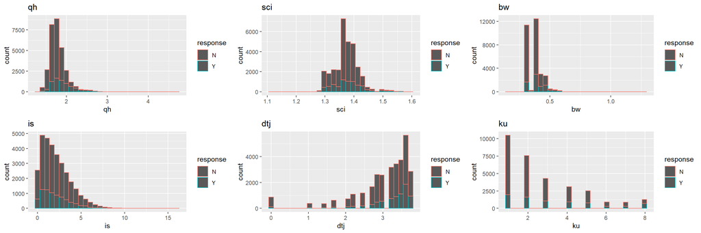

```r
hplt.1 <- ggplot(data = pp.data.1, aes(x = qh, color = response)) +
                geom_histogram() +
                ggtitle("qh")
hplt.2 <- ggplot(data = pp.data.1, aes(x = sci, color = response)) +
                geom_histogram() +
                ggtitle("sci")
hplt.3 <- ggplot(data = pp.data.1, aes(x = bw, color = response)) +
                geom_histogram() +
                ggtitle("bw")
hplt.4 <- ggplot(data = pp.data.1, aes(x = is, color = response)) +
                geom_histogram() +
                ggtitle("is")
hplt.5 <- ggplot(data = pp.data.1, aes(x = dtj, color = response)) +
                geom_histogram() +
                ggtitle("dtj")
hplt.6 <- ggplot(data = pp.data.1, aes(x = ku, color = response)) +
                geom_histogram() +
                ggtitle("ku")
grid.arrange(hplt.1,
             hplt.2,
             hplt.3,
             hplt.4,
             hplt.5,
             hplt.6,
             ncol = 3)
```

qh, sci, and bw are somewhat normal. is, dtj, and ku have shapes that can be transformed into near normal if required.

Scatter plots and correlation coefficients for continuous data and response:

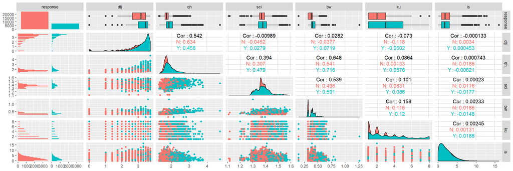

```r
# pair plot of continuous data
ggpairs(pp.data.1[,1:7],
        mapping = ggplot2::aes(colour=response),
        progress = FALSE) +
    theme(legend.position = "bottom")
```

Larger boxplots of continuous data separated by response

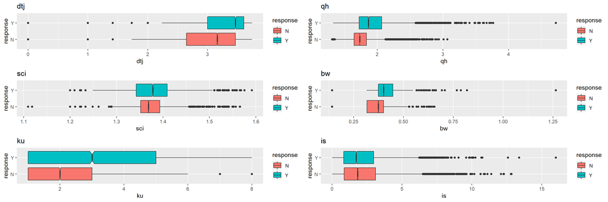

```r
bxplt.1 <- ggplot(data = pp.data.1, aes(x = response, y = dtj, fill = response)) +
                geom_boxplot(notch = TRUE) +
                ggtitle("dtj") +
                coord_flip()
bxplt.2 <- ggplot(data = pp.data.1, aes(x = response, y = qh, fill = response)) +
                geom_boxplot(notch = TRUE) +
                ggtitle("qh") +
                coord_flip()
bxplt.3 <- ggplot(data = pp.data.1, aes(x = response, y = sci, fill = response)) +
                geom_boxplot(notch = TRUE) +
                ggtitle("sci") +
                coord_flip()
bxplt.4 <- ggplot(data = pp.data.1, aes(x = response, y = bw, fill = response)) +
                geom_boxplot(notch = TRUE) +
                ggtitle("bw") +
                coord_flip()
bxplt.5 <- ggplot(data = pp.data.1, aes(x = response, y = ku, fill = response)) +
                geom_boxplot(notch = TRUE) +
                ggtitle("ku") +
                coord_flip()
bxplt.6 <- ggplot(data = pp.data.1, aes(x = response, y = is, fill = response)) +
                geom_boxplot(notch = TRUE) +
                ggtitle("is") +
                coord_flip()
grid.arrange(bxplt.1,
             bxplt.2,
             bxplt.3,
             bxplt.4,
             bxplt.5,
             bxplt.6,
             ncol = 2)
```

dtj, qh, and bw have decent separation of their means between the Y and N responses. These are good indicators.

ku, sci and is have some separation and may be of importance.

### Scatter Plots of Continuous and Discrete Data

Selected scatter plots that show banding and clusting with the reponse and other categorical variables.

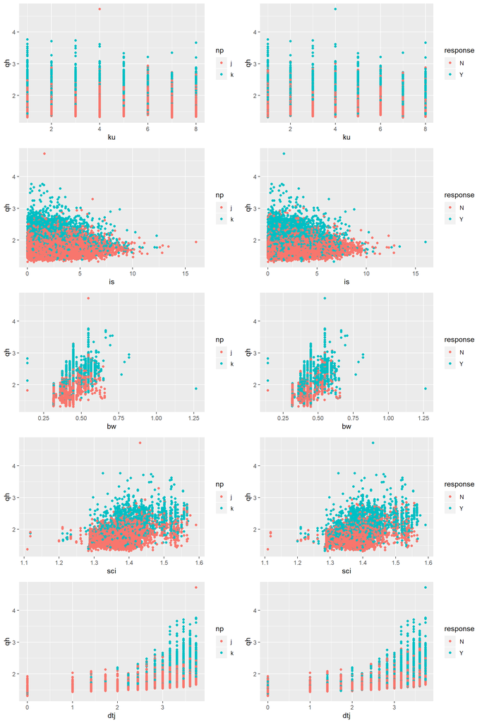

```r
#there is a decent linear pattern present within qh
#clear clusters can be seen with the np variable
scat.1 <- ggplot(pp.data.1, aes(x=ku, y=qh, color = np)) +
                geom_point()
scat.2 <- ggplot(pp.data.1, aes(x=is, y=qh, color = np)) +
                geom_point()
scat.3 <- ggplot(pp.data.1, aes(x=bw, y=qh, color = np)) +
                geom_point()
scat.4 <- ggplot(pp.data.1, aes(x=sci, y=qh, color = np)) +
                geom_point()
scat.5 <- ggplot(pp.data.1, aes(x=dtj, y=qh, color = np)) +
                geom_point()

scat.6 <- ggplot(pp.data.1, aes(x=ku, y=qh, color = response)) +
                geom_point()
scat.7 <- ggplot(pp.data.1, aes(x=is, y=qh, color = response)) +
                geom_point()
scat.8 <- ggplot(pp.data.1, aes(x=bw, y=qh, color = response)) +
                geom_point()
scat.9 <- ggplot(pp.data.1, aes(x=sci, y=qh, color = response)) +
                geom_point()
scat.10 <- ggplot(pp.data.1, aes(x=dtj, y=qh, color = response)) +
                geom_point()

grid.arrange(scat.1, scat.6,
             scat.2, scat.7,
             scat.3, scat.8,
             scat.4, scat.9,
             scat.5, scat.10,
             ncol = 2)
```

For the np variable, treatment j is related to lower qh values and treatment k are higher qh values. It is clear that qh and np are both highly important to predicting success.

dtj and bw vs qh have the cleanest separation of clusters which again indicates a higher significance of dtj and bw with the highest being qh and np.

Some banding can be seen in the is vs qh plots over several categorical variables:

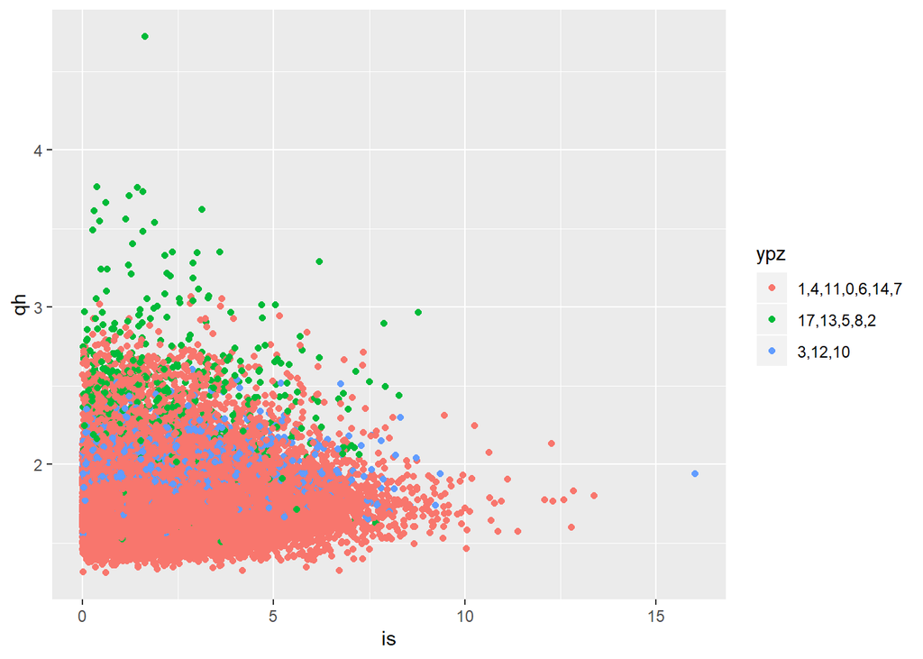

```r
# banding can be seen in these plots
ggplot(pp.data.1, aes(x=is, y=qh, color = ypz)) +
    geom_point()
```

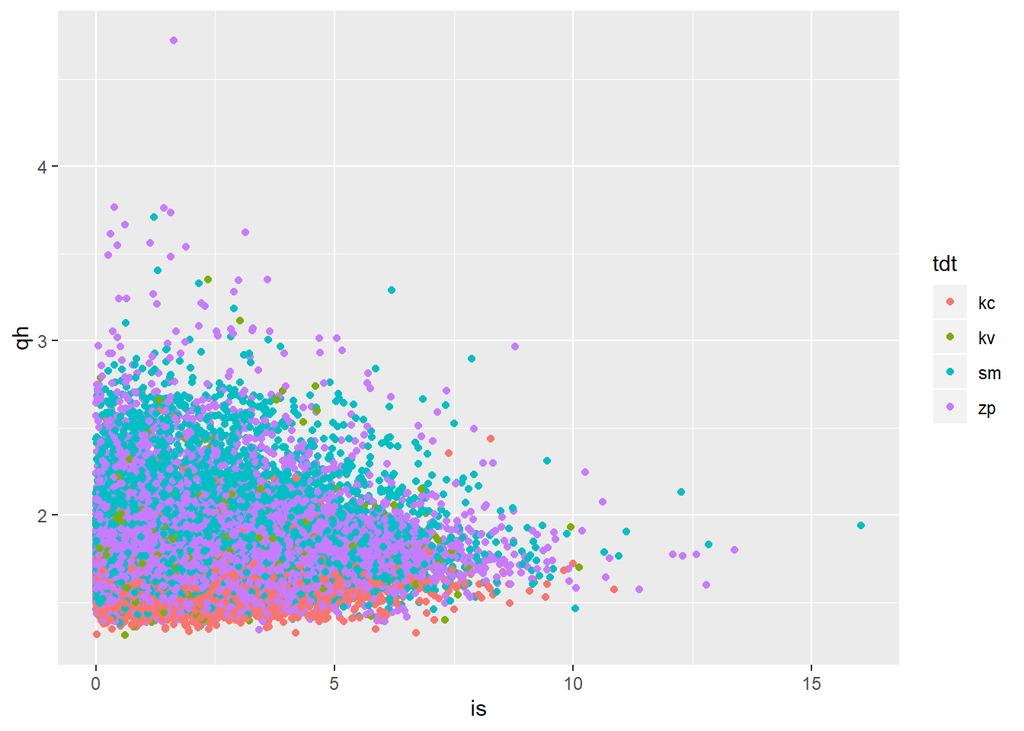

```r
ggplot(pp.data.1, aes(x=is, y=qh, color = tdt)) +
    geom_point()
```

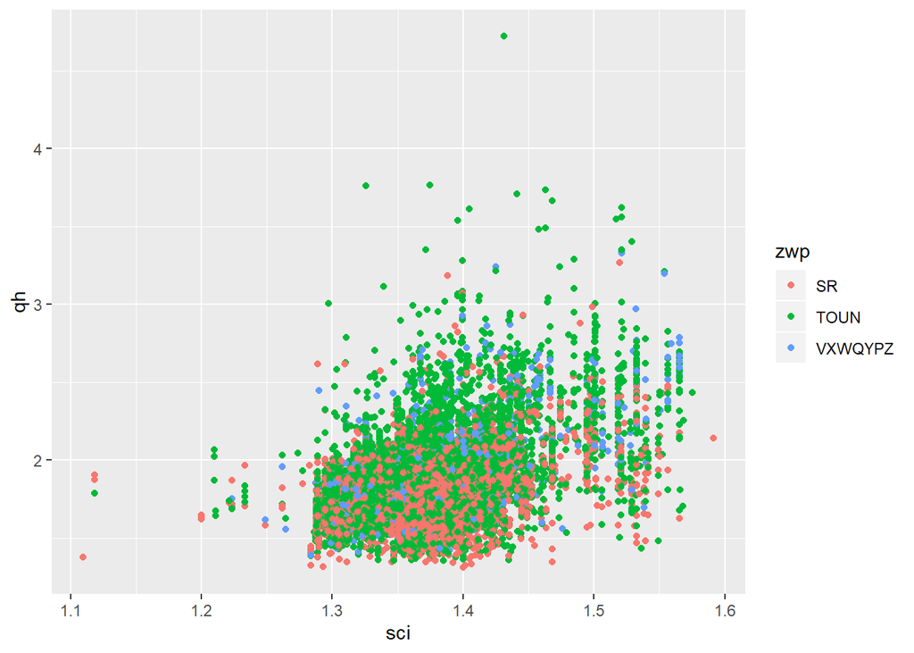

```r
ggplot(pp.data.1, aes(x=sci, y=qh, color = zwp)) +
    geom_point()
```

## PCA

Preprocess Data for PCA:

```r
# isolate separate data for PCA
pca.data <- pp.data.1

#convert factor data to numeric
pca.data[discrete.vec] <- sapply(pca.data[discrete.vec],as.numeric)
head(pca.data)
```

```
##        response     dtj       qh      sci      bw ku      is wc zwp wi ypz tdt
## 165931        1 3.31662 1.619306 1.358321 0.31623  2 0.24077  3   1  2   1   1
## 241964        1 0.00000 1.465870 1.421907 0.44698  8 3.76180  2   1  1   1   3
## 387089        2 3.46410 2.011248 1.427199 0.44721  4 2.49990  2   2  1   1   4
## 433922        2 3.31662 1.915616 1.410130 0.38729  3 2.47710  2   3  1   3   3
## 175120        1 3.74166 1.740224 1.361948 0.31623  1 4.17080  2   1  1   1   4
## 353214        1 2.23607 1.656426 1.313058 0.39988  1 2.94250  2   1  1   1   4
##        sb xt np
## 165931  2  1  1
## 241964  2  1  1
## 387089  2  1  1
## 433922  2  1  2
## 175120  2  1  1
## 353214  2  1  1
```

Look for relationship betweens mean and variation to understand the importance of scaling:

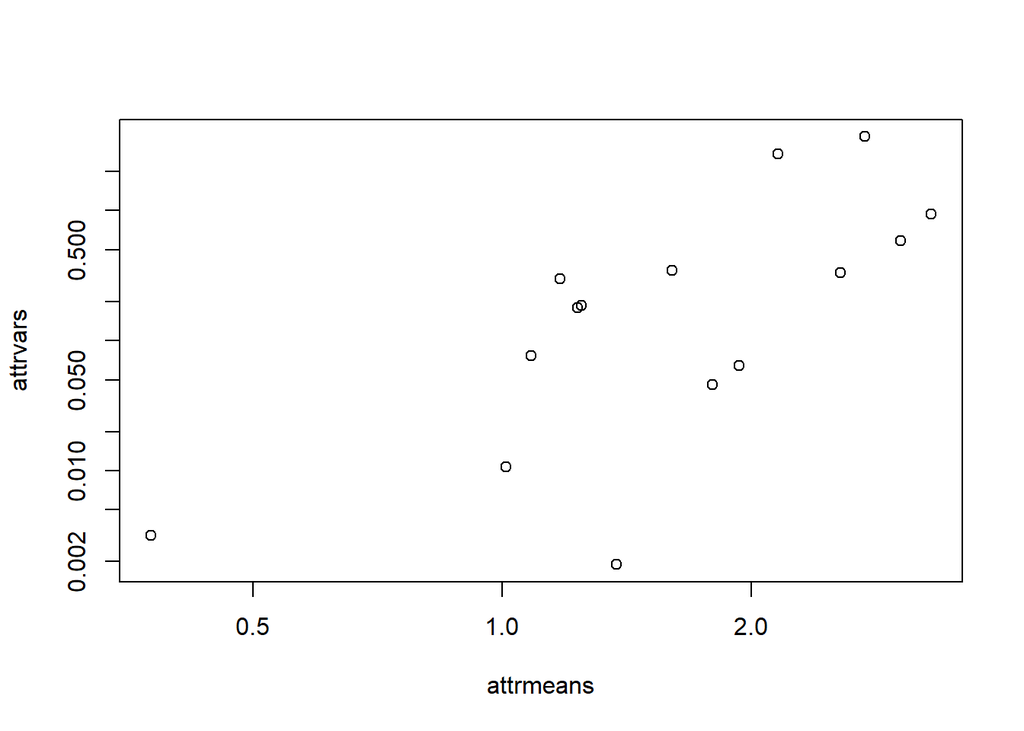

```r
attrmeans <- apply(pca.data,2,mean)
attrvars <- apply(pca.data,2,var)
plot(attrmeans,attrvars,log="xy")
```

```r
summary(attrmeans)
```

```
##    Min. 1st Qu.  Median    Mean 3rd Qu.    Max.
##   0.376   1.204   1.604   1.774   2.359   3.296
```

```r
summary(attrvars)
```

```
##     Min.  1st Qu.   Median     Mean  3rd Qu.     Max.
## 0.001901 0.055212 0.185711 0.630181 0.465678 3.681767
```

Scaling is necessary due to the log relationship between mean and variance of the variables.

Create the PCA model and plot:

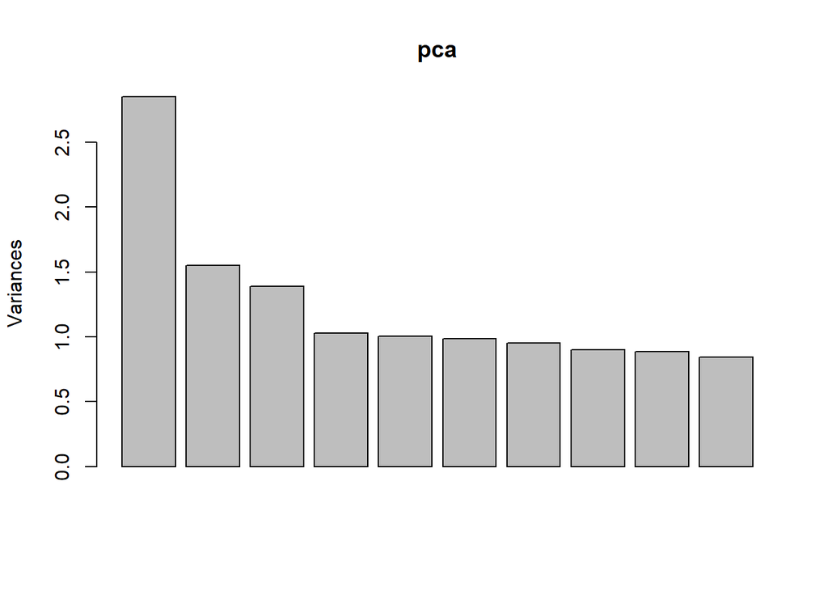

```r
#PCA model
pca <- prcomp(pca.data, scale. = TRUE, center = TRUE)
plot(pca)
```